# FIFA_WORLD_CUP_PROJECT_BY_DOLLY_PANTHI

## **FIFA World Cup Analysis**

## Problem Statement

With FIFA is in the blood of many people of the world. You are tasked to tell the story of unsung analysts who put great efforts to provide accurate data to answer every question of fans.

The FIFA World Cup is a global football competition contested by the various football-playing nations of the world. It is contested every four years and is the most prestigious and important trophy in the sport of football.

The World Cups dataset shows all information about all the World Cups in history, while the World Cup Matches dataset shows all the results from the matches contested as part of the cups.

Find key metrics and factors that influence the World Cup win. Do your own research and come up with your findings.

### Task 1 - Load and study the data

Import the libraries that will be used in this notebook

```python
# Load "numpy" and "pandas" for manipulating numbers and data frames
# Load "matplotlib.pyplot" and "seaborn" for data visualisation
import pandas as pd
import numpy as np
import matplotlib.pyplot as plt
import seaborn as sns
```

```python
# Step 1: Load and Explore Data
world_cups = pd.read_csv('/content/WorldCups.csv')
world_cup_matches = pd.read_csv('/content/WorldCupMatches.csv')
world_cup_players = pd.read_csv('/content/WorldCupPlayers.csv')
```

```python
# Display the first few rows of each dataset
world_cups.head()
```

|  | Year | Country | Winner | Runners-Up | Third | Fourth | GoalsScored | QualifiedTeams | MatchesPlayed | Attendance |
| --- | --- | --- | --- | --- | --- | --- | --- | --- | --- | --- |
| 0 | 1930 | Uruguay | Uruguay | Argentina | USA | Yugoslavia | 70 | 13 | 18 | 590.549 |
| 1 | 1934 | Italy | Italy | Czechoslovakia | Germany | Austria | 70 | 16 | 17 | 363.000 |
| 2 | 1938 | France | Italy | Hungary | Brazil | Sweden | 84 | 15 | 18 | 375.700 |
| 3 | 1950 | Brazil | Uruguay | Brazil | Sweden | Spain | 88 | 13 | 22 | 1.045.246 |
| 4 | 1954 | Switzerland | Germany FR | Hungary | Austria | Uruguay | 140 | 16 | 26 | 768.607 |

```python
# Take a brief look at the data
world_cup_matches.head()
```

|  | Year | Datetime | Stage | Stadium | City | Home Team Name | Home Team Goals | Away Team Goals | Away Team Name | Win conditions | Attendance | Half-time Home Goals | Half-time Away Goals | Referee | Assistant 1 | Assistant 2 | RoundID | MatchID | Home Team Initials | Away Team Initials |
| --- | --- | --- | --- | --- | --- | --- | --- | --- | --- | --- | --- | --- | --- | --- | --- | --- | --- | --- | --- | --- |
| 0 | 1930.0 | 13 Jul 1930 - 15:00 | Group 1 | Pocitos | Montevideo | France | 4.0 | 1.0 | Mexico |  | 4444.0 | 3.0 | 0.0 | LOMBARDI Domingo (URU) | CRISTOPHE Henry (BEL) | REGO Gilberto (BRA) | 201.0 | 1096.0 | FRA | MEX |
| 1 | 1930.0 | 13 Jul 1930 - 15:00 | Group 4 | Parque Central | Montevideo | USA | 3.0 | 0.0 | Belgium |  | 18346.0 | 2.0 | 0.0 | MACIAS Jose (ARG) | MATEUCCI Francisco (URU) | WARNKEN Alberto (CHI) | 201.0 | 1090.0 | USA | BEL |
| 2 | 1930.0 | 14 Jul 1930 - 12:45 | Group 2 | Parque Central | Montevideo | Yugoslavia | 2.0 | 1.0 | Brazil |  | 24059.0 | 2.0 | 0.0 | TEJADA Anibal (URU) | VALLARINO Ricardo (URU) | BALWAY Thomas (FRA) | 201.0 | 1093.0 | YUG | BRA |
| 3 | 1930.0 | 14 Jul 1930 - 14:50 | Group 3 | Pocitos | Montevideo | Romania | 3.0 | 1.0 | Peru |  | 2549.0 | 1.0 | 0.0 | WARNKEN Alberto (CHI) | LANGENUS Jean (BEL) | MATEUCCI Francisco (URU) | 201.0 | 1098.0 | ROU | PER |
| 4 | 1930.0 | 15 Jul 1930 - 16:00 | Group 1 | Parque Central | Montevideo | Argentina | 1.0 | 0.0 | France |  | 23409.0 | 0.0 | 0.0 | REGO Gilberto (BRA) | SAUCEDO Ulises (BOL) | RADULESCU Constantin (ROU) | 201.0 | 1085.0 | ARG | FRA |

```python
# Take a brief look at the data
world_cup_players.head()
```

|  | RoundID | MatchID | Team Initials | Coach Name | Line-up | Shirt Number | Player Name | Position | Event |
| --- | --- | --- | --- | --- | --- | --- | --- | --- | --- |
| 0 | 201 | 1096 | FRA | CAUDRON Raoul (FRA) | S | 0 | Alex THEPOT | GK | NaN |
| 1 | 201 | 1096 | MEX | LUQUE Juan (MEX) | S | 0 | Oscar BONFIGLIO | GK | NaN |
| 2 | 201 | 1096 | FRA | CAUDRON Raoul (FRA) | S | 0 | Marcel LANGILLER | NaN | G40' |
| 3 | 201 | 1096 | MEX | LUQUE Juan (MEX) | S | 0 | Juan CARRENO | NaN | G70' |
| 4 | 201 | 1096 | FRA | CAUDRON Raoul (FRA) | S | 0 | Ernest LIBERATI | NaN | NaN |

```python
# Look at basic information about the dataframe
world_cups.info()
```

```
<class 'pandas.core.frame.DataFrame'>
RangeIndex: 20 entries, 0 to 19
Data columns (total 10 columns):
 #   Column          Non-Null Count  Dtype
---  ------          --------------  -----
 0   Year            20 non-null     int64
 1   Country         20 non-null     object
 2   Winner          20 non-null     object
 3   Runners-Up      20 non-null     object
 4   Third           20 non-null     object
 5   Fourth          20 non-null     object
 6   GoalsScored     20 non-null     int64
 7   QualifiedTeams  20 non-null     int64
 8   MatchesPlayed   20 non-null     int64
 9   Attendance      20 non-null     object
dtypes: int64(4), object(6)
memory usage: 1.7+ KB
```

```python
# Look at basic information about the dataframe
world_cup_players.info()
```

```
<class 'pandas.core.frame.DataFrame'>
RangeIndex: 37784 entries, 0 to 37783
Data columns (total 9 columns):
 #   Column         Non-Null Count  Dtype
---  ------         --------------  -----
 0   RoundID        37784 non-null  int64
 1   MatchID        37784 non-null  int64
 2   Team Initials  37784 non-null  object
 3   Coach Name     37784 non-null  object
 4   Line-up        37784 non-null  object
 5   Shirt Number   37784 non-null  int64
 6   Player Name    37784 non-null  object
 7   Position       4143 non-null   object
 8   Event          9069 non-null   object
dtypes: int64(3), object(6)
memory usage: 2.6+ MB
```

```python
# Look at basic information about the dataframe
world_cup_matches.info()
```

```
<class 'pandas.core.frame.DataFrame'>
RangeIndex: 4572 entries, 0 to 4571
Data columns (total 24 columns):
 #   Column                Non-Null Count  Dtype
---  ------                --------------  -----
 0   Year                  852 non-null    float64
 1   Datetime              852 non-null    object
 2   Stage                 852 non-null    object
 3   Stadium               852 non-null    object
 4   City                  852 non-null    object
 5   Home Team Name        852 non-null    object
 6   Home Team Goals       852 non-null    float64
 7   Away Team Goals       852 non-null    float64
 8   Away Team Name        852 non-null    object
 9   Win conditions        852 non-null    object
```

[output cut: 16 more lines]

World Cup Matches Dataset Observations

Dataset Overview:

Total Rows: 852 Total Columns: 24

Key Columns:

Year: Year of the match. Home Team Goals / Away Team Goals: Goals scored by home and away teams. Attendance: Number of spectators. Outcome Indicators: Home Team Win, Away Team Win, Draw.

```python
world_cups.isnull().sum()
```

```
Year              0
Country           0
Winner            0
Runners-Up        0
Third             0
Fourth            0
GoalsScored       0
QualifiedTeams    0
MatchesPlayed     0
Attendance        0
dtype: int64
```

The World Cup dataset contains information on each tournament, including the year, host country, winner, runners-up, and third and fourth place teams. It also records key metrics such as total goals scored, number of qualified teams, matches played, and overall attendance. There are no missing values in this dataset.

```python
world_cup_matches.isnull().sum()
```

```
Year                    3720
Datetime                3720
Stage                   3720
Stadium                 3720
City                    3720
Home Team Name          3720
Home Team Goals         3720
Away Team Goals         3720
Away Team Name          3720
Win conditions          3720
Attendance              3722
Half-time Home Goals    3720
Half-time Away Goals    3720
Referee                 3720
Assistant 1             3720
Assistant 2             3720
RoundID                 3720
MatchID                 3720
Home Team Initials      3720
Away Team Initials      3720
dtype: int64
```

```python
world_cup_players.isnull().sum()
```

```
RoundID              0
MatchID              0
Team Initials        0
Coach Name           0
Line-up              0
Shirt Number         0
Player Name          0
Position         33641
Event            28715
dtype: int64
```

```python
# Explore the world_cup_matches dataset
print(world_cup_matches.head())  # Show the first few rows
print(world_cup_matches.info())  # Show data types and summary statistics
print(world_cup_matches.describe())  # Show summary statistics
```

```
     Year              Datetime    Stage         Stadium         City  \
0  1930.0  13 Jul 1930 - 15:00   Group 1         Pocitos  Montevideo
1  1930.0  13 Jul 1930 - 15:00   Group 4  Parque Central  Montevideo
2  1930.0  14 Jul 1930 - 12:45   Group 2  Parque Central  Montevideo
3  1930.0  14 Jul 1930 - 14:50   Group 3         Pocitos  Montevideo
4  1930.0  15 Jul 1930 - 16:00   Group 1  Parque Central  Montevideo

  Home Team Name  Home Team Goals  Away Team Goals Away Team Name  \
0         France              4.0              1.0         Mexico
1            USA              3.0              0.0        Belgium
2     Yugoslavia              2.0              1.0         Brazil
3        Romania              3.0              1.0           Peru
4      Argentina              1.0              0.0         France

  Win conditions  Attendance  Half-time Home Goals  Half-time Away Goals  \
0                     4444.0                   3.0                   0.0
1                    18346.0                   2.0                   0.0
2                    24059.0                   2.0                   0.0
3                     2549.0                   1.0                   0.0
4                    23409.0                   0.0                   0.0

                  Referee               Assistant 1  \
0  LOMBARDI Domingo (URU)     CRISTOPHE Henry (BEL)
1       MACIAS Jose (ARG)  MATEUCCI Francisco (URU)
2     TEJADA Anibal (URU)   VALLARINO Ricardo (URU)
3   WARNKEN Alberto (CHI)       LANGENUS Jean (BEL)
4     REGO Gilberto (BRA)      SAUCEDO Ulises (BOL)

                  Assistant 2  RoundID  MatchID Home Team Initials  \
0         REGO Gilberto (BRA)    201.0   1096.0                FRA
1       WARNKEN Alberto (CHI)    201.0   1090.0                USA
2         BALWAY Thomas (FRA)    201.0   1093.0                YUG
3    MATEUCCI Francisco (URU)    201.0   1098.0                ROU
4  RADULESCU Constantin (ROU)    201.0   1085.0                ARG

  Away Team Initials
0                MEX
1                BEL
2                BRA
3                PER
```

[output cut: 33 more lines]

```
min    1930.000000         0.000000         0.000000    2000.000000
25%    1970.000000         1.000000         0.000000   30000.000000
50%    1990.000000         2.000000         1.000000   41579.500000
75%    2002.000000         3.000000         2.000000   61374.500000
max    2014.000000        10.000000         7.000000  173850.000000

       Half-time Home Goals  Half-time Away Goals       RoundID       MatchID
count            852.000000            852.000000  8.520000e+02  8.520000e+02
mean               0.708920              0.428404  1.066177e+07  6.134687e+07
std                0.937414              0.691252  2.729613e+07  1.110572e+08
min                0.000000              0.000000  2.010000e+02  2.500000e+01
25%                0.000000              0.000000  2.620000e+02  1.188750e+03
50%                0.000000              0.000000  3.370000e+02  2.191000e+03
75%                1.000000              1.000000  2.497220e+05  4.395006e+07
max                6.000000              5.000000  9.741060e+07  3.001865e+08
```

```python
# Get the column names of the dataframe
print("world_cups column names:")
print(world_cups.columns)
print("\nworld_cup_matches column names:")
print(world_cup_matches.columns)
```

```
world_cups column names:
Index(['Year', 'Country', 'Winner', 'Runners-Up', 'Third', 'Fourth',
       'GoalsScored', 'QualifiedTeams', 'MatchesPlayed', 'Attendance'],
      dtype='object')

world_cup_matches column names:
Index(['Year', 'Datetime', 'Stage', 'Stadium', 'City', 'Home Team Name',
       'Home Team Goals', 'Away Team Goals', 'Away Team Name',
       'Win conditions', 'Attendance', 'Half-time Home Goals',
       'Half-time Away Goals', 'Referee', 'Assistant 1', 'Assistant 2',
       'RoundID', 'MatchID', 'Home Team Initials', 'Away Team Initials'],
      dtype='object')
```

# Step 3: Merge Datasets

```python
# Merge world_cup_matches with world_cups
merged_matches = pd.merge(world_cup_matches, world_cups, how='inner', on='Year')

# Merge the resulting dataset with world_cup_players
# Here, we assume that the 'MatchID' column exists in both datasets
merged_data = pd.merge(merged_matches, world_cup_players, how='inner', on='MatchID')

# Display the merged dataset
print(merged_data.head())
```

```
     Year              Datetime    Stage  Stadium         City Home Team Name  \
0  1930.0  13 Jul 1930 - 15:00   Group 1  Pocitos  Montevideo          France
1  1930.0  13 Jul 1930 - 15:00   Group 1  Pocitos  Montevideo          France
2  1930.0  13 Jul 1930 - 15:00   Group 1  Pocitos  Montevideo          France
3  1930.0  13 Jul 1930 - 15:00   Group 1  Pocitos  Montevideo          France
4  1930.0  13 Jul 1930 - 15:00   Group 1  Pocitos  Montevideo          France

   Home Team Goals  Away Team Goals Away Team Name Win conditions  ...  \
0              4.0              1.0         Mexico                 ...
1              4.0              1.0         Mexico                 ...
2              4.0              1.0         Mexico                 ...
3              4.0              1.0         Mexico                 ...
4              4.0              1.0         Mexico                 ...

   MatchesPlayed  Attendance_y  RoundID_y Team Initials           Coach Name  \
0             18       590.549        201           FRA  CAUDRON Raoul (FRA)
1             18       590.549        201           MEX     LUQUE Juan (MEX)
2             18       590.549        201           FRA  CAUDRON Raoul (FRA)
3             18       590.549        201           MEX     LUQUE Juan (MEX)
4             18       590.549        201           FRA  CAUDRON Raoul (FRA)

  Line-up  Shirt Number       Player Name Position Event
0       S             0       Alex THEPOT       GK   NaN
1       S             0   Oscar BONFIGLIO       GK   NaN
2       S             0  Marcel LANGILLER      NaN  G40'
3       S             0      Juan CARRENO      NaN  G70'
4       S             0   Ernest LIBERATI      NaN   NaN

[5 rows x 37 columns]
```

# Step 4: Feature Engineering

```python
# Example: Creating a goal difference feature
merged_data['Goal_Difference'] = merged_data['Home Team Goals'] - merged_data['Away Team Goals']

# Display the dataset with the new feature
print(merged_data.head())
```

```
     Year              Datetime    Stage  Stadium         City Home Team Name  \
0  1930.0  13 Jul 1930 - 15:00   Group 1  Pocitos  Montevideo          France
1  1930.0  13 Jul 1930 - 15:00   Group 1  Pocitos  Montevideo          France
2  1930.0  13 Jul 1930 - 15:00   Group 1  Pocitos  Montevideo          France
3  1930.0  13 Jul 1930 - 15:00   Group 1  Pocitos  Montevideo          France
4  1930.0  13 Jul 1930 - 15:00   Group 1  Pocitos  Montevideo          France

   Home Team Goals  Away Team Goals Away Team Name Win conditions  ...  \
0              4.0              1.0         Mexico                 ...
1              4.0              1.0         Mexico                 ...
2              4.0              1.0         Mexico                 ...
3              4.0              1.0         Mexico                 ...
4              4.0              1.0         Mexico                 ...

   Attendance_y  RoundID_y  Team Initials           Coach Name Line-up  \
0       590.549        201            FRA  CAUDRON Raoul (FRA)       S
1       590.549        201            MEX     LUQUE Juan (MEX)       S
2       590.549        201            FRA  CAUDRON Raoul (FRA)       S
3       590.549        201            MEX     LUQUE Juan (MEX)       S
4       590.549        201            FRA  CAUDRON Raoul (FRA)       S

  Shirt Number       Player Name  Position Event Goal_Difference
0            0       Alex THEPOT        GK   NaN             3.0
1            0   Oscar BONFIGLIO        GK   NaN             3.0
2            0  Marcel LANGILLER       NaN  G40'             3.0
3            0      Juan CARRENO       NaN  G70'             3.0
4            0   Ernest LIBERATI       NaN   NaN             3.0

[5 rows x 38 columns]
```

# Step 5: Analysis and Visualization

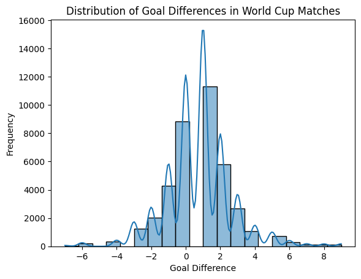

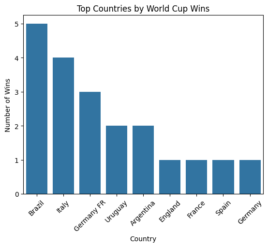

```python
import seaborn as sns
import matplotlib.pyplot as plt

# Example analysis: Distribution of Goal Differences in World Cup Matches
sns.histplot(merged_data['Goal_Difference'], bins=20, kde=True)
plt.title('Distribution of Goal Differences in World Cup Matches')
plt.xlabel('Goal Difference')
plt.ylabel('Frequency')
plt.show()

# Example analysis: Top countries by World Cup wins
top_countries = world_cups['Winner'].value_counts()
sns.barplot(x=top_countries.index, y=top_countries.values)
plt.title('Top Countries by World Cup Wins')
plt.xlabel('Country')
plt.ylabel('Number of Wins')
plt.xticks(rotation=45)
plt.show()
```

# Summary

```python
# Calculate the number of wins, draws, and losses for each team
world_cup_matches['Home Team Win'] = np.where(world_cup_matches['Home Team Goals'] > world_cup_matches['Away Team Goals'], 1, 0)
world_cup_matches['Away Team Win'] = np.where(world_cup_matches['Away Team Goals'] > world_cup_matches['Home Team Goals'], 1, 0)
world_cup_matches['Draw'] = np.where(world_cup_matches['Home Team Goals'] == world_cup_matches['Away Team Goals'], 1, 0)
```

```python
# Calculate the total number of wins, draws, and losses for each team
team_results = world_cup_matches.groupby('Home Team Initials').agg({'Home Team Win': 'sum', 'Draw': 'sum'})
team_results.columns = ['Wins', 'Draws']
team_results['Losses'] = world_cup_matches.groupby('Home Team Initials')['Away Team Win'].sum()
```

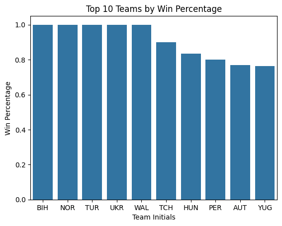

```python
# Calculate the win percentage for each team
team_results['Win Percentage'] = team_results['Wins'] / (team_results['Wins'] + team_results['Draws'] + team_results['Losses'])

# Plot the top 10 teams by win percentage
sns.barplot(x=team_results['Win Percentage'].nlargest(10).index, y=team_results['Win Percentage'].nlargest(10).values)
plt.title('Top 10 Teams by Win Percentage')
plt.xlabel('Team Initials')
plt.ylabel('Win Percentage')
plt.show()
```

```python
# Calculate the correlation between attendance and home team wins
attendance_correlation = world_cup_matches.groupby('Home Team Initials')['Attendance'].first().corr(world_cup_matches.groupby('Home Team Initials')['Home Team Win'].first())
print('Correlation between attendance and home team wins:', attendance_correlation)

# Calculate the correlation between half-time score and final score
half_time_correlation = world_cup_matches.groupby('Home Team Initials')['Half-time Home Goals'].first().corr(world_cup_matches.groupby('Home Team Initials')['Home Team Goals'].first())
print('Correlation between half-time score and final score:', half_time_correlation)
```

```
Correlation between attendance and home team wins: -0.1674341782248803
Correlation between half-time score and final score: 0.7591773558308684
```

### **Summary of Correlation Analysis Correlation between Attendance and Home Team Winning:**

The correlation coefficient is -0.167434.

This indicates a weak negative relationship between attendance and the home team winning. In other words, as attendance increases, the likelihood of the home team winning slightly decreases. However, the correlation is quite weak and may not be statistically significant.

### **Correlation between Half-Time Score and Final Score:**

The correlation coefficient is 0.7591. This indicates a strong positive relationship between the half-time score and the final score. This means that higher half-time scores are associated with higher final scores, suggesting that teams that perform well in the first half tend to maintain their performance in the second half

## **Which countries have won the most World Cups?**

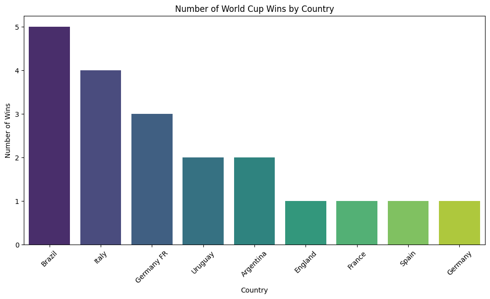

```python
# Number of World Cup wins by country
world_cup_wins = world_cups['Winner'].value_counts()

# Visualization
plt.figure(figsize=(12, 6))
sns.barplot(x=world_cup_wins.index, y=world_cup_wins.values, palette="viridis")
plt.title('Number of World Cup Wins by Country')
plt.xlabel('Country')
plt.ylabel('Number of Wins')
plt.xticks(rotation=45)
plt.show()
```

## **Top 3 countries have won the most World Cups**

## 1. Brazil

## 2. Italy

## 3. Germany FR

## **How has the number of goals scored changed over the years?**

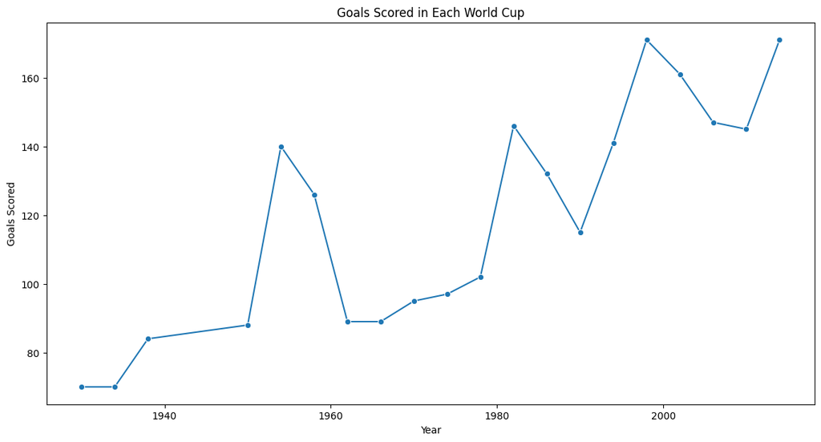

```python
# Goals scored in each World Cup
plt.figure(figsize=(14, 7))
sns.lineplot(data=world_cups, x='Year', y='GoalsScored', marker='o')
plt.title('Goals Scored in Each World Cup')
plt.xlabel('Year')
plt.ylabel('Goals Scored')
plt.show()
```

## The graph shows the number of goals scored in each World Cup from 1930 to 2014.

## The number of goals scored has generally increased over time, with a few dips along the way.

## The highest number of goals scored was in the 2014 World Cup, with 171 goals.

# What is the average attendance for World Cup tournaments over the years?

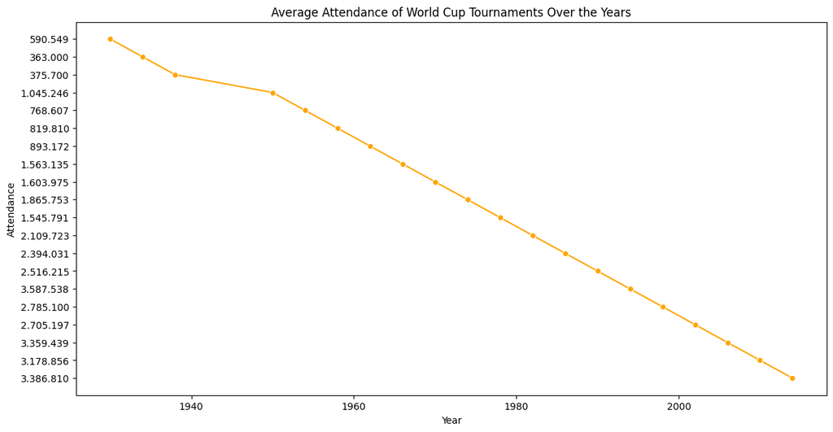

```python
# Average attendance over the years
plt.figure(figsize=(14, 7))
sns.lineplot(data=world_cups, x='Year', y='Attendance', marker='o', color='orange')
plt.title('Average Attendance of World Cup Tournaments Over the Years')
plt.xlabel('Year')
plt.ylabel('Attendance')
plt.show()
```

The graph shows the average attendance of World Cup tournaments over the years.

# **World Cup Matches Dataset**

What is the distribution of match outcomes (Home win, Away win, Draw)?

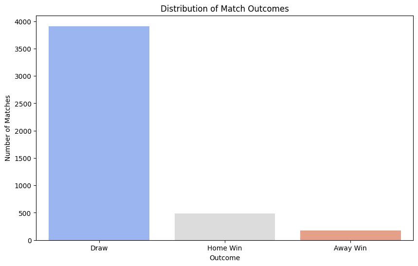

```python
# Determine match outcomes
match_outcomes = world_cup_matches[['Home Team Name', 'Home Team Goals', 'Away Team Goals', 'Away Team Name']].copy()
match_outcomes['Outcome'] = match_outcomes.apply(
    lambda row: 'Home Win' if row['Home Team Goals'] > row['Away Team Goals']
    else ('Away Win' if row['Home Team Goals'] < row['Away Team Goals'] else 'Draw'), axis=1)

# Distribution of match outcomes
outcome_counts = match_outcomes['Outcome'].value_counts()

# Visualization
plt.figure(figsize=(10, 6))
sns.barplot(x=outcome_counts.index, y=outcome_counts.values, palette="coolwarm")
plt.title('Distribution of Match Outcomes')
plt.xlabel('Outcome')
plt.ylabel('Number of Matches')
plt.show()
```

The graph shows the distribution of match outcomes in a football league.

# How do home and away goals compare in World Cup matches?

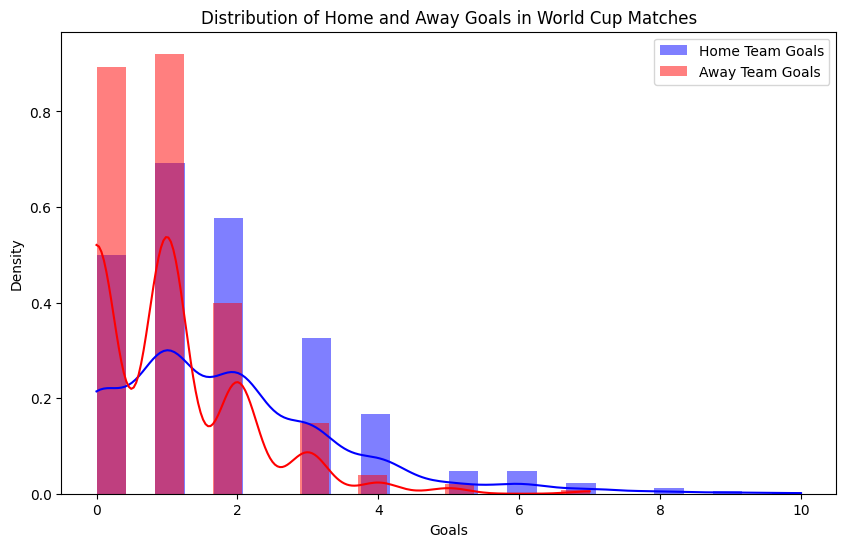

```python
# Comparison of home and away goals
plt.figure(figsize=(10, 6))
sns.histplot(match_outcomes['Home Team Goals'], color='blue', label='Home Team Goals', kde=True, stat="density", linewidth=0)
sns.histplot(match_outcomes['Away Team Goals'], color='red', label='Away Team Goals', kde=True, stat="density", linewidth=0)
plt.title('Distribution of Home and Away Goals in World Cup Matches')
plt.xlabel('Goals')
plt.ylabel('Density')
plt.legend()
plt.show()
```

The graph shows the distribution of home and away goals in World Cup matches. The x-axis represents the number of goals scored, and the y-axis represents the density. The blue bars and line represent the home team goals, while the red bars and line represent the away team goals. The graph shows that home teams tend to score more goals than away teams.

### The distribution of goals is skewed to the right, meaning that there are more matches with a low number of goals than with a high number of goals.

World Cup Players Dataset

What are the most common player positions?

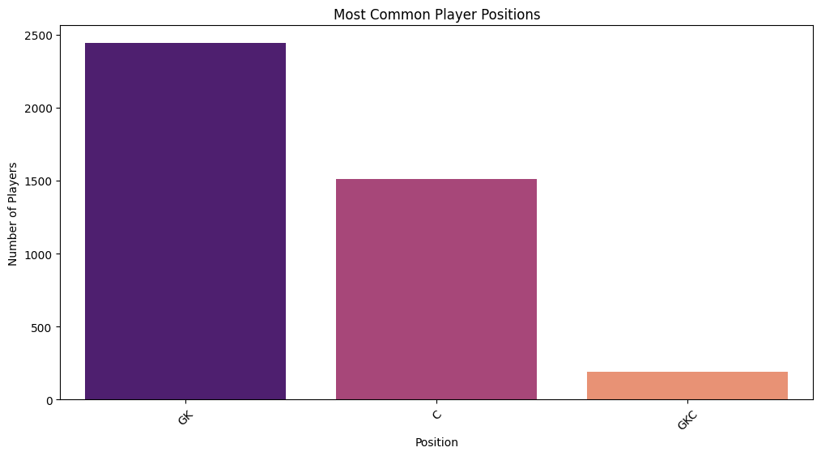

```python
# Most common player positions
player_positions = world_cup_players['Position'].value_counts()

# Visualization
plt.figure(figsize=(12, 6))
sns.barplot(x=player_positions.index, y=player_positions.values, palette="magma")
plt.title('Most Common Player Positions')
plt.xlabel('Position')
plt.ylabel('Number of Players')
plt.xticks(rotation=45)
plt.show()
```

## The graph shows the most common player positions in a dataset.

## The position GK is the most common with 2400+ players. The second most common position is C with 1500+ players.

# How many players have come from each country?

[figure not shown]

```python
# Number of players from each country
players_by_country = world_cup_players['Team Initials'].value_counts()

# Visualization
plt.figure(figsize=(12, 6))
sns.barplot(x=players_by_country.index, y=players_by_country.values, palette="cubehelix")
plt.title('Number of Players from Each Country')
plt.xlabel('Country')
plt.ylabel('Number of Players')
plt.xticks(rotation=45)
plt.show()
```

The graph shows the number of players from each country.

Step 3: Integrate and Analyze Combined Data Let's now combine the datasets to find deeper insights.

Merge the Datasets

```python
# Merge world_cup_matches with world_cups on 'Year'
merged_matches = pd.merge(world_cup_matches, world_cups, how='inner', on='Year')

# Merge the resulting dataset with world_cup_players on 'MatchID'
if 'MatchID' in merged_matches.columns and 'MatchID' in world_cup_players.columns:
    merged_data = pd.merge(merged_matches, world_cup_players, how='inner', on='MatchID')
else:
    print("MatchID column is not present in both datasets. Please check the column names.")

# Display the merged dataset
print(merged_data.head())
```

```
     Year              Datetime    Stage  Stadium         City Home Team Name  \
0  1930.0  13 Jul 1930 - 15:00   Group 1  Pocitos  Montevideo          France
1  1930.0  13 Jul 1930 - 15:00   Group 1  Pocitos  Montevideo          France
2  1930.0  13 Jul 1930 - 15:00   Group 1  Pocitos  Montevideo          France
3  1930.0  13 Jul 1930 - 15:00   Group 1  Pocitos  Montevideo          France
4  1930.0  13 Jul 1930 - 15:00   Group 1  Pocitos  Montevideo          France

   Home Team Goals  Away Team Goals Away Team Name Win conditions  ...  \
0              4.0              1.0         Mexico                 ...
1              4.0              1.0         Mexico                 ...
2              4.0              1.0         Mexico                 ...
3              4.0              1.0         Mexico                 ...
4              4.0              1.0         Mexico                 ...

   MatchesPlayed  Attendance_y  RoundID_y Team Initials           Coach Name  \
0             18       590.549        201           FRA  CAUDRON Raoul (FRA)
1             18       590.549        201           MEX     LUQUE Juan (MEX)
2             18       590.549        201           FRA  CAUDRON Raoul (FRA)
3             18       590.549        201           MEX     LUQUE Juan (MEX)
4             18       590.549        201           FRA  CAUDRON Raoul (FRA)

  Line-up  Shirt Number       Player Name Position Event
0       S             0       Alex THEPOT       GK   NaN
1       S             0   Oscar BONFIGLIO       GK   NaN
2       S             0  Marcel LANGILLER      NaN  G40'
3       S             0      Juan CARRENO      NaN  G70'
4       S             0   Ernest LIBERATI      NaN   NaN

[5 rows x 41 columns]
```

What are the top countries by World Cup player participation?

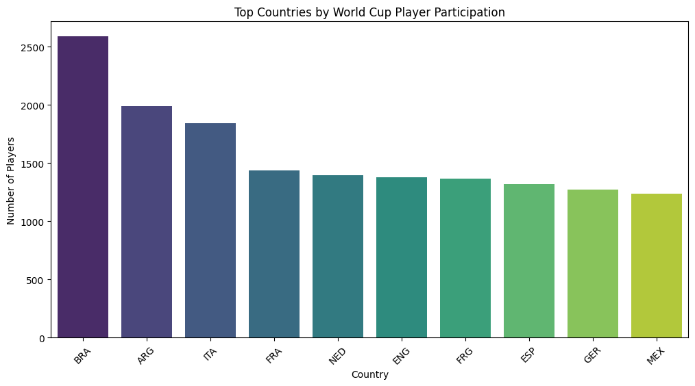

```python
# Top countries by player participation
players_by_country = merged_data['Team Initials'].value_counts().head(10)

# Visualization
plt.figure(figsize=(12, 6))
sns.barplot(x=players_by_country.index, y=players_by_country.values, palette="viridis")
plt.title('Top Countries by World Cup Player Participation')
plt.xlabel('Country')
plt.ylabel('Number of Players')
plt.xticks(rotation=45)
plt.show()
```

# This bar chart shows the top 10 countries with the most World Cup player participation.

### Brazil leads the way with over 2,500 players participating, followed by Argentina with nearly 2,000.

The chart provides a great overview of which countries have the most representation in the World Cup. It is important to remember that this is a snapshot in time and does not take into account the history of the tournament or changes in participation over time.

# **CONCLUSION**